# R Notebook

```r
library(tidyverse)
library(cluster)
library(factoextra)
library(dendextend)
library(janitor)
```

Clustering

```r
mall_customers <- read_csv("mall_customers.csv")
```

```r
mall_customers
```

| CustomerID | Gender | Age | Annual Income (k$) | Spending Score (1-100) |
| --- | --- | --- | --- | --- |
| 1 | Male | 19 | 15 | 39 |
| 2 | Male | 21 | 15 | 81 |
| 3 | Female | 20 | 16 | 6 |
| 4 | Female | 23 | 16 | 77 |
| 5 | Female | 31 | 17 | 40 |
| 6 | Female | 22 | 17 | 76 |
| 7 | Female | 35 | 18 | 6 |
| 8 | Female | 23 | 18 | 94 |
| 9 | Male | 64 | 19 | 3 |
| 10 | Female | 30 | 19 | 72 |

[output cut: 190 more lines]

```r
head(mall_customers)
```

| CustomerID | Gender | Age | Annual Income (k$) | Spending Score (1-100) |
| --- | --- | --- | --- | --- |
| 1 | Male | 19 | 15 | 39 |
| 2 | Male | 21 | 15 | 81 |
| 3 | Female | 20 | 16 | 6 |
| 4 | Female | 23 | 16 | 77 |
| 5 | Female | 31 | 17 | 40 |
| 6 | Female | 22 | 17 | 76 |

```r
NA
```

```r
summary(mall_customers)
```

```
   CustomerID        Gender               Age        Annual Income (k$) Spending Score (1-100)
 Min.   :  1.00   Length:200         Min.   :18.00   Min.   : 15.00     Min.   : 1.00
 1st Qu.: 50.75   Class :character   1st Qu.:28.75   1st Qu.: 41.50     1st Qu.:34.75
 Median :100.50   Mode  :character   Median :36.00   Median : 61.50     Median :50.00
 Mean   :100.50                      Mean   :38.85   Mean   : 60.56     Mean   :50.20
 3rd Qu.:150.25                      3rd Qu.:49.00   3rd Qu.: 78.00     3rd Qu.:73.00
 Max.   :200.00                      Max.   :70.00   Max.   :137.00     Max.   :99.00
```

```r
mall_customers_clean <- mall_customers %>%
  clean_names() %>%
  select(gender, age, annual_income_k, spending_score_1_100)
mall_customers_clean
```

| gender | age | annual_income_k | spending_score_1_100 |
| --- | --- | --- | --- |
| Male | 19 | 15 | 39 |
| Male | 21 | 15 | 81 |
| Female | 20 | 16 | 6 |
| Female | 23 | 16 | 77 |
| Female | 31 | 17 | 40 |
| Female | 22 | 17 | 76 |
| Female | 35 | 18 | 6 |
| Female | 23 | 18 | 94 |
| Male | 64 | 19 | 3 |
| Female | 30 | 19 | 72 |

[output cut: 190 more lines]

1.You have been provided some customer data from a shopping centre. Do some exploratory analysis on the data. Comment on findings. A. There appear to be 5 loose clusters on the graph below. With a clear concentration and cluster around the x-axis = 55 (annual_income_k) and y-axis = 50 (spending_score_1_1000

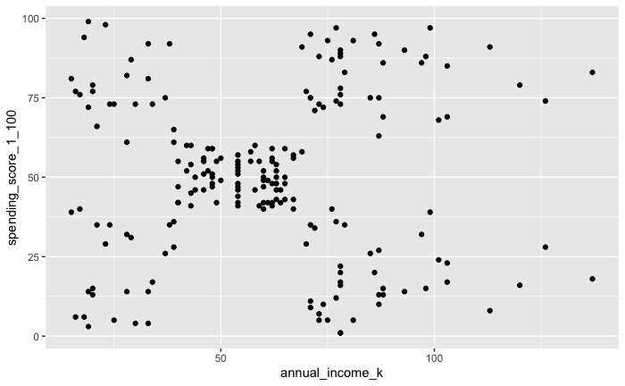

```r
mall_customers_clean_plot <- mall_customers_clean %>%
  select(c(annual_income_k, spending_score_1_100))

ggplot(mall_customers_clean, aes(annual_income_k, spending_score_1_100)) +
  geom_point()
```

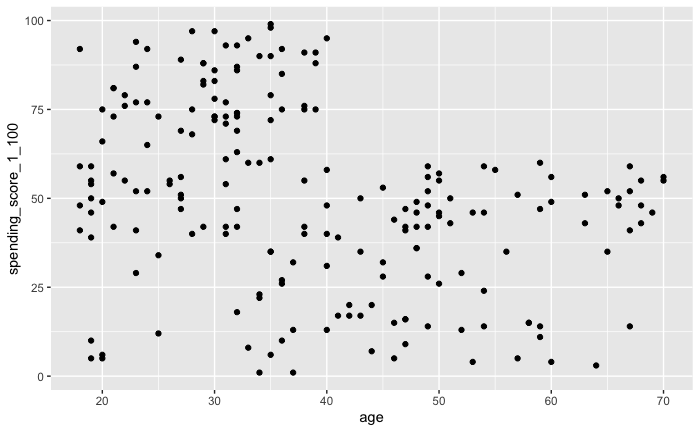

```r
mall_customers_clean_age <- mall_customers_clean %>%
  select(c(age, spending_score_1_100))

ggplot(mall_customers_clean, aes(age, spending_score_1_100)) +
  geom_point()
```

2.We are interested in creating a marketing campaign to target customers based on their spending score and annual income. Perform a k-means clustering to find if there are meaningful clusters in the data to target the customers. A. Yes there are 5 clear identified clusters

```r
mall_customers_clean_scale <- mall_customers_clean %>%
                      mutate_all(scale)

summary(mall_customers_clean_scale)
```

[output not shown]

3.Perform k-means clustering and chose a value of k.

```r
library(factoextra)
```

Each of the methods of choosing k: 3.1 Elbow method A. From below I read 2 options k = 3 or k = 5. k = 5 looks to be clearer

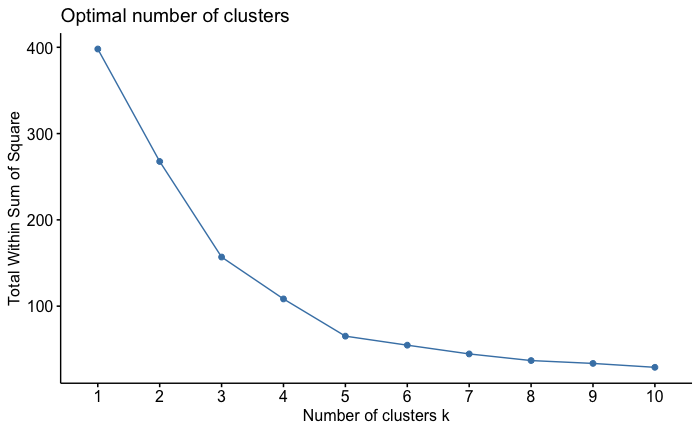

```r
fviz_nbclust(mall_customers_clean_scale, kmeans, method = "wss", nstart = 25)
```

3.2 Silhouette coefficient A. K = 5 is optimal here

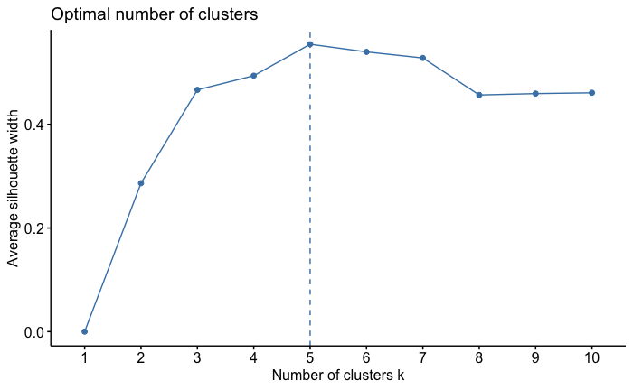

```r
fviz_nbclust(mall_customers_clean_scale, kmeans, method = "silhouette", nstart = 25)
```

3.3 Gap statistic A. Result K = 1

```
Clustering k = 1,2,..., K.max (= 10): .. done
Bootstrapping, b = 1,2,..., B (= 100)  [one "." per sample]:
.................................................. 50
.................................................. 100
```

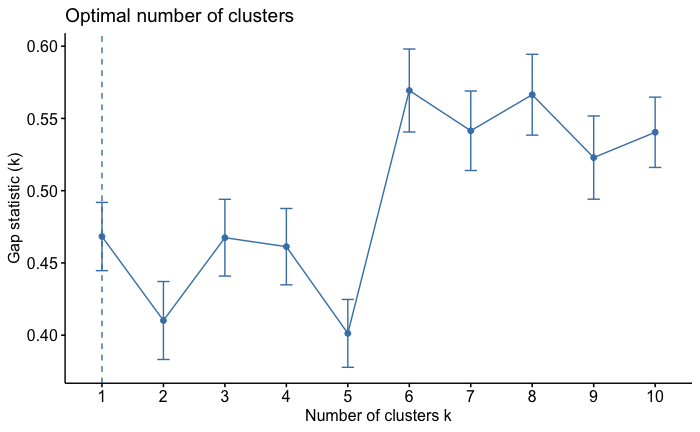

```r
fviz_nbclust(mall_customers_clean_scale, kmeans, method = "gap_stat")
```

A. From reading all of the above clusters K = 3 or K = 5 give optimal results. I’m going for k = 5

4.Visualise the clustering for your chosen value of k.

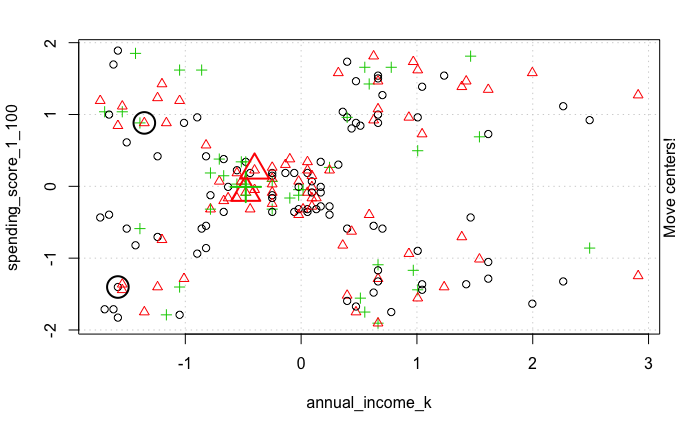

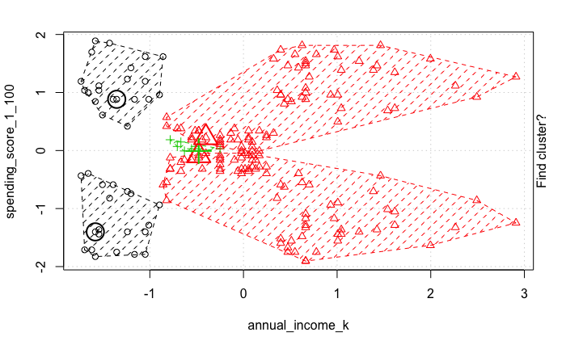

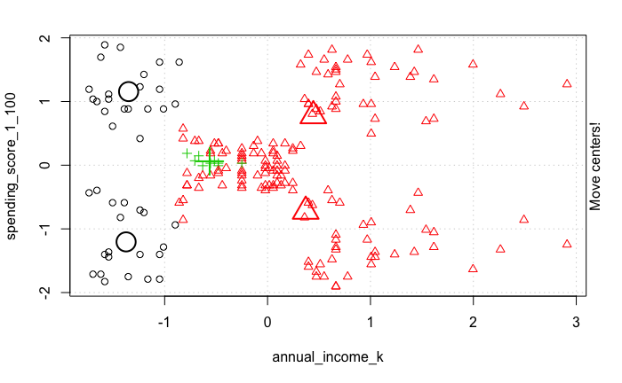

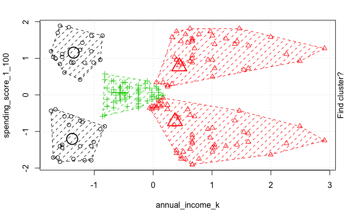

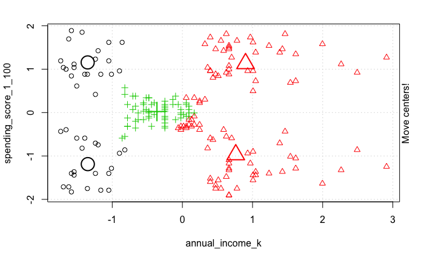

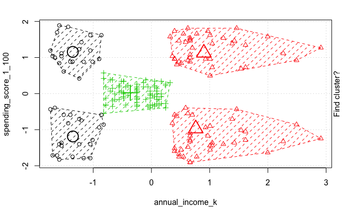

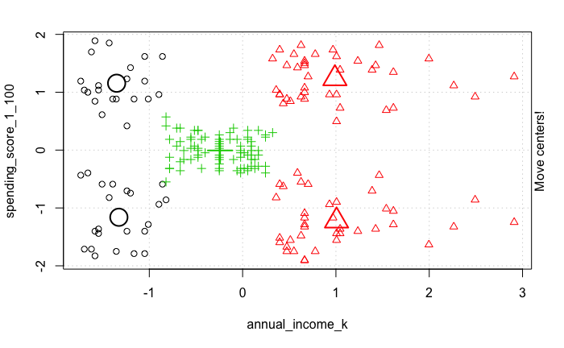

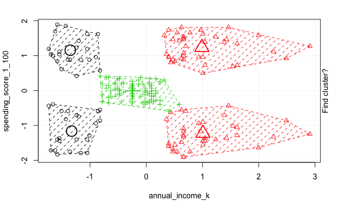

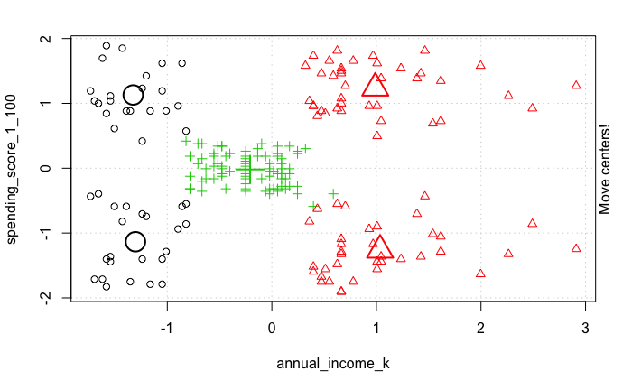

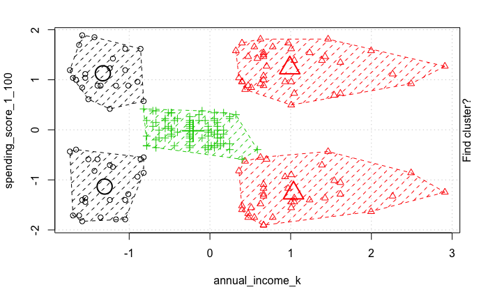

```r
library(animation)

mall_customers_clean_scale %>%
  kmeans.ani(centers = 5)
```

5.Do you think the clustering seems a good fit for this data? A. Yes I think the 5 clusters give a good clear fit for the data

6.Comment on the attributes on one or two of the clusters (maybe even give them a label if you like - like in section 4.1 of the ‘Segmentation & clustering intro’ lesson). While there are 5 clusters shown above plotting Annual income vs Spending score, it is clear form the graph factoring in age there highest spenders are all predominately under the age of 40 - presumably as the are likely to not have children and also have a higher disposable income. 6.1 The under 40 with high disposable income (top left) 6.2 The over 40 with low disposable income